# Omówienie pakietu ‘AID’

Jędrzej Sarna

2024-01-21

# Wprowadzenie

Pracując z różnymi zestawami danych, narzędzia statystyczne, takie jak pakiet AID, odgrywają kluczową rolę. Pakiet AID, ze szczególnym uwzględnieniem transformacji Boxa-Coxa, dostarcza niezbędnych narzędzi do przetwarzania i analizy danych w odpowiedni sposób.

Transformacja Boxa-Coxa jest wykorzystywana do przekształcania danych, tak aby lepiej spełniały one standardowe założenia statystyczne, takie jak normalność rozkładu czy homoscedastyczność. Dzięki temu, można dokonywać bardziej wiarygodnych analiz danych.

Pakiet AID oferuje nie tylko samo narzędzie transformacji, ale również zaawansowane podejścia graficzne i statystyczne do oceny skuteczności przekształceń. Wykorzystanie wykresów takich jak histogramy czy wykresy Q-Q pozwala na wizualną ocenę, czy dane po transformacji są bliższe rozkładowi normalnemu. Dodatkowo, za pomocą testów statystycznych, takich jak test Shapiro-Wilka, użytkownicy mogą formalnie zweryfikować skuteczność przeprowadzonej transformacji.

Kluczową cechą pakietu AID jest również możliwość obliczenia średnich i przedziałów ufności dla danych po transformacji zwrotnej. Ta funkcjonalność jest kluczowa w interpretacji wyników i prezentacji danych w ich pierwotnej formie, umożliwiając lepsze zrozumienie i komunikację wyników badania.

W tym dokumencie zostają przedstawione funkcje i zbiory danych zawarte w pakiecie AID wraz z przykładami użycia.

## Specyfikacje pakietu na podstawie dokumentacji

**Typ**: Pakiet  
**Tytuł**: Transformacja Potęgowa Boxa-Coxa  
**Wersja**: 2.9  
**Data**: 2023-09-13  
**Zależności**: R (>= 3.2.0)  
**Importuje**: MASS, tseries, nortest, ggplot2, graphics, psych, stats, meta, stringr  
**Sugeruje**: onewaytests  
**Autor**: Osman Dag [aut, cre], Muhammed Ali Yilmaz [aut], Ozgur Asar [ctb], Ozlem Ilk [ctb]  
**Opiekun**: Osman Dag osman.dag@outlook.com  
**Opis**: Wykonuje transformację potęgową Boxa-Coxa dla różnych celów, podejścia graficzne, ocenia sukces transformacji za pomocą testów i wykresów, oblicza średnią i przedział ufności dla danych po transformacji zwrotnej.  
**Licencja**: GPL (>= 2)  
**Wymaga kompilacji**: nie  
**Repozytorium**: CRAN  
**Data/Publikacja**: 2023-09-13 11:42:34 UTC

## Instalacja pakietu

Aby zainstalować pakiet AID w R, należy wykonać polecenie `install.packages("AID")`. Po zainstalowaniu, pakiet ten można załadować do środowiska R za pomocą polecenia `library(AID)`.

```r
install.packages("AID")
library(AID)
```

# Zbiory Danych

Rozpoczynając analizę pakietu AID, warto najpierw przyjrzeć się dostępnym w nim zbiorom danych. Zbiory danych w pakietach R zazwyczaj służą do demonstracji możliwości pakietu, testowania funkcji, a także jako materiały edukacyjne.

## AADT - *Average Annual Daily Traffic Data*

**Opis**  
Dane dotyczące średniego rocznego ruchu dziennego, zebrane z bazy danych Departamentu Transportu Minnesoty.

**Użycie**  
`data(AADT)`

**Format**

Ramka danych zawierająca 121 obserwacji na następujące 8 zmiennych:

- `aadt`: średni roczny ruch dzienny na odcinku drogi
- `ctypop`: populacja hrabstwa
- `lanes`: liczba pasów ruchu na odcinku drogi
- `width`: szerokość odcinka drogi (w stopach)
- `control`: czynnik z poziomami: kontrola dostępu; brak kontroli dostępu
- `class`: czynnik z poziomami: międzystanowa wiejska; nie-międzystanowa wiejska; międzystanowa miejska; nie-międzystanowa miejska
- `truck`: dostępność ciężarówek na odcinku drogi
- `locale`: czynnik z poziomami: wiejski; miejski, populacja <= 50,000; miejski, populacja > 50,000

```r
data(AADT)
summary(AADT)
```

```
##       aadt            ctypop           lanes           width
##  Min.   :   201   Min.   :  7716   Min.   :2.000   Min.   :19.00
##  1st Qu.:  1769   1st Qu.: 25717   1st Qu.:2.000   1st Qu.:24.00
##  Median :  8666   Median :113571   Median :2.000   Median :24.00
##  Mean   : 19438   Mean   :263428   Mean   :3.099   Mean   :31.12
##  3rd Qu.: 21535   3rd Qu.:459784   3rd Qu.:4.000   3rd Qu.:38.00
##  Max.   :155547   Max.   :941411   Max.   :8.000   Max.   :68.00
##               control                   class        truck
##  access control   :27   rural interstate   : 8   Min.   :1.000
##  no access control:94   rural noninterstate:56   1st Qu.:1.000
##                         urban interstate   :18   Median :5.000
##                         urban noninterstate:39   Mean   :3.372
##                                                  3rd Qu.:5.000
##                                                  Max.   :5.000
##                          locale
##  rural                      :64
##  urban, population <= 50,000:39
##  urban, population > 50,000 :18
##
##
##
```

## grades - *Student Grades Data*

**Opis**  
Ogólne oceny studentów z klasy prowadzonej przez dr. Ozlem Ilk.

**Użycie**  
`data(grades)`

**Format**

Ramka danych zawierająca 42 obserwacje na następującą 1 zmienną:

- `grades`: wektor numeryczny dla ocen studentów

```r
data(grades)
summary(grades)
```

```
##      grades
##  Min.   : 0.20
##  1st Qu.:54.10
##  Median :64.60
##  Mean   :65.35
##  3rd Qu.:79.95
##  Max.   :95.00
```

## textile - *Textile Data*

**Opis**  
Liczba cykli do awarii przędzy wełnianej.

**Użycie**  
`data(textile)`

**Format**

Ramka danych zawierająca 27 obserwacji na następującą 1 zmienną:

- `textile`: wektor numeryczny reprezentujący liczbę cykli do awarii

```r
data(textile)
summary(textile)
```

```
##     textile
##  Min.   :  90.0
##  1st Qu.: 312.0
##  Median : 566.0
##  Mean   : 861.3
##  3rd Qu.:1105.0
##  Max.   :3636.0
```

# Transformacje Boxa-Coxa

## boxcoxfr - *Transformacja Boxa-Coxa dla Jednoczynnikowej ANOVA*

**Opis**  
`boxcoxfr` wykonuje transformację Boxa-Coxa dla jednoczynnikowej analizy wariancji (ANOVA). Jest przydatna, gdy normalność lub/i homogeniczność wariancji nie są spełnione przy porównywaniu dwóch lub więcej grup.

**Użycie**

```
boxcoxfr(y, x, option = "both", lambda = seq(-3, 3, 0.01), lambda2 = NULL,
        tau = 0.05, alpha = 0.05, verbose = TRUE)
```

**Argumenty**

- `y`: wektor numeryczny wartości danych.
- `x`: wektor lub obiekt typu factor, który określa grupę dla odpowiadających elementów `y`.
- `opcja`: ciąg znaków do wyboru pożądanej opcji celu transformacji. “nor” i “var” to opcje, które szukają transformacji dla zapewnienia odpowiednio normalności grup i homogeniczności wariancji. “both” to opcja, która szuka transformacji dla zapewnienia zarówno normalności grup, jak i homogeniczności wariancji. Domyślnie ustawiona na “both”.
- `lambda`: wektor zawierający sekwencję dopuszczalnych wartości lambda. Domyślnie ustawiony na (-3, 3) z krokiem 0.01.
- `lambda2`: wartość numeryczna dodatkowego parametru przesunięcia (shifting parameter). Domyślnie ustawiona na `lambda2 = 0`.
- `tau`: parametr określający obszar dopuszczalny dla konstrukcji obszaru dopuszczalnego. Domyślnie ustawiony na 0.05. Jeśli `tau = 0`, zwraca estymator największej wiarygodności parametru transformacji.
- `alpha`: poziom istotności do sprawdzenia normalności i homogeniczności wariancji po transformacji. Domyślnie ustawiony na `alpha = 0.05`.
- `verbose`: wartość logiczna określająca, czy wyniki mają być wyświetlane w konsoli R.

**Szczegóły**

Oznaczając $y$ jako zmienną w oryginalnej skali i $y'$ jako zmienną przekształconą, transformacja potęgowa Boxa-Coxa jest zdefiniowana przez:

$$y' =
\begin{cases}
\frac{y^\lambda - 1}{\lambda} & \text{jeśli } \lambda \neq 0 \\
\log(y) & \text{jeśli } \lambda = 0
\end{cases}$$

Jeśli dane zawierają jakiekolwiek obserwacje niedodatnie, można uwzględnić parametr przesunięcia $\lambda_2$ w transformacji, która jest zdefiniowana przez:

$$y' =
\begin{cases}
\frac{(y + \lambda_2)^\lambda - 1}{\lambda} & \text{jeśli }
\lambda \neq 0 \\
\log(y + \lambda_2) & \text{jeśli } \lambda = 0
\end{cases}$$

Do estymacji parametru transformacji używa się metody największej wiarygodności w obszarze dopuszczalnym (MLEFR). MLEFR maksymalizuje funkcję wiarygodności w obszarze dopuszczalnym, skonstruowanym przy użyciu testu Shapiro-Wilka i testu Bartletta. Po transformacji, normalność danych w każdej grupie i homogeniczność wariancji są oceniane odpowiednio przy użyciu testu Shapiro-Wilka i testu Bartletta.

**Wartości zwracane**

Lista o klasie `"boxcoxfr"` zawierająca następujące elementy:

- `method`: metoda zastosowana w algorytmie
- `lambda.hat`: oszacowana wartość lambda
- `lambda2`: dodatkowy parametr przesunięcia
- `shapiro`: ramka danych zawierająca wyniki testu Shapiro-Wilka w celu oceny normalności grup
- `bartlett`: macierz zawierająca wyniki testu Bartletta w celu oceny homogeniczności wariancji
- `alpha`: poziom istotności do oceny założeń
- `tf.data`: przekształcony zbiór danych
- `x`: obiekt typu factor, określający grupę dla odpowiadających elementów zmiennej `y`
- `y.name`: nazwa zmiennej `y`
- `x.name`: nazwa zmiennej `x`

**Przykład użycia**

```r
library(AID)
data(AADT)
out <- boxcoxfr(AADT$aadt, AADT$class) #stosuje transformację Boxa-Coxa do zmiennej 'aadt'z 'class' jako zmienną grupującą
```

```
##
##   Box-Cox power transformation
## ---------------------------------------------------------------------
##
##   lambda.hat : 0.07
##
##
##   Shapiro-Wilk normality test for transformed data (alpha = 0.05)
## -------------------------------------------------------------------
##                 Level statistic    p.value Normality
## 1    rural interstate 0.9616863 0.82600329       YES
## 2 rural noninterstate 0.9583807 0.05108728       YES
## 3    urban interstate 0.9259602 0.16481355       YES
## 4 urban noninterstate 0.9636063 0.23477931       YES
##
##
##   Bartlett's homogeneity test for transformed data (alpha = 0.05)
## -------------------------------------------------------------------
##   Level statistic   p.value Homogeneity
## 1   All  4.257035 0.2350132         YES
## ---------------------------------------------------------------------
```

**Komentarz:**

- `lambda.hat : 0.07` - optymalny parametr transformacji Boxa-Coxa w tym przypadku wynosi 0.07.
- `Shapiro-Wilk normality test for transformed data (alpha = 0.05)` - wyniki testu normalności Shapiro-Wilka dla przekształconych danych. Test ten sprawdza, czy dane po transformacji mają rozkład normalny. Wartości ‘statistic’ i ‘p.value’ dla każdej grupy (‘rural interstate’, ‘rural noninterstate’, ‘urban interstate’, ‘urban noninterstate’) pokazują wyniki testu. Wszystkie grupy mają ‘p.value’ wyższe niż 0.05 (próg alfa), co oznacza, że nie ma podstaw do odrzucenia hipotezy o normalności rozkładu danych w każdej grupie (‘Normality: YES’).
- `Bartlett's homogeneity test for transformed data (alpha = 0.05)` - wyniki testu homogeniczności wariancji Bartletta dla przekształconych danych.
  - Level: All - odnosi się do wszystkich grup danych.
  - statistic 4.257035 i p.value 0.2350132: Statystyka testowa i p-wartość dla testu Bartletta. Ponieważ p-wartość jest większa niż 0.05, nie ma podstaw do odrzucenia hipotezy o jednorodności wariancji między grupami (‘Homogeneity: YES’).

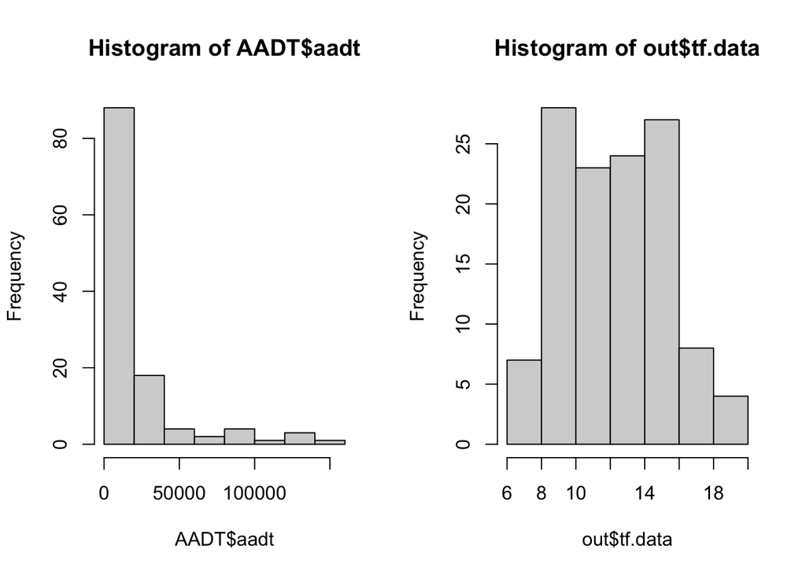

```r
par(mfrow=c(1,2))
hist(AADT$aadt) #oryginalne dane 'aadt'
hist(out$tf.data)#przekształcone dane 'aadt'
```

**Komentarz:**

Dane przed tranformacją nie mają rozkładu zbliżonego do normalnego (lewy histogram), a po transformacji przypominają już rozkład normalny. (prawy histogram)

```r
library(onewaytests)
AADT$tf.aadt <- out$tf.data #dodaje przekształcone dane 'aadt' jako nową kolumnę 'tf.aadt'
result<-aov.test(tf.aadt ~ class, data = AADT)
```

```
##
##   One-Way Analysis of Variance (alpha = 0.05)
## -------------------------------------------------------------
##   data : tf.aadt and class
##
##   statistic  : 77.59829
##   num df     : 3
##   denom df   : 117
##   p.value    : 1.066575e-27
##
##   Result     : Difference is statistically significant.
## -------------------------------------------------------------
```

**Komentarz:**

- `statistic` - wartość statystyki testowej, używana do określenia, czy różnice między grupami są statystycznie znaczące.
- `num_df` oraz `denom_df` - odpowiadnio oznacza liczbę grup minus jeden oraz całkowitą liczbe obserwacji minus liczba grup.
- `p.value` - mierzy prawdopodobieństwo uzyskania obserwowanych wyników, lub bardziej ekstremalnych, przy założeniu, że nie ma żadnej różnicy między grupami (tzn. pod hipotezą zerową).
- `Result` - Ponieważ p-wartość jest znacznie mniejsza niż standardowy próg istotności statystycznej (0.05), wynik jest statystycznie istotny. Oznacza to, że istnieją znaczące różnice między średnimi wartościami zmiennej `tf.aadt` w różnych grupach zmiennej `class`.

## boxcoxlm - *Transformacja Boxa-Coxa dla Modeli Liniowych*

**Opis**  
Funkcja `boxcoxlm` wykonuje transformację Boxa-Coxa dla modeli liniowych i dostarcza analizy graficznej rezultatów po transformacji.

**Użycie**

```
boxcoxlm(x, y, method = "lse", lambda = seq(-3,3,0.01), lambda2 = NULL,
        plot = TRUE, alpha = 0.05, verbose = TRUE)
```

**Argumenty**

- `x`: macierz o wymiarach $n \times p$, gdzie n to liczba obserwacji, a p to liczba zmiennych.
- `y`: wektor zmiennej odpowiedzi.
- `method`: ciąg znaków określający metodę estymacji parametru transformacji Boxa-Coxa. Dostępne opcje to “sw” (test Shapiro-Wilka), “ad” (test Andersona-Darlinga), “cvm” (test Cramera-von Misesa), “pt” (test Chi-kwadrat Pearsona), “sf” (test Shapiro-Francia), “lt” (test Lillieforsa), “jb” (test Jarque-Bera), “mle” (estymacja metodą największej wiarygodności) i “lse” (estymacja metodą najmniejszych kwadratów). Domyślnie ustawiona na “lse”.
- `lambda`: wektor zawierający sekwencję kandydatów na wartość lambda. Domyślnie ustawiony na (-3, 3) z krokiem 0.01.
- `lambda2`: wartość numeryczna dodatkowego parametru przesunięcia. Domyślnie ustawiona na `lambda2 = 0`.
- `plot`: wartość logiczna określająca, czy generować wykres histogramu z linią gęstości oraz QQ-plot dla reszt przed i po transformacji. Domyślnie ustawiona na `TRUE`.
- `alpha`: poziom istotności do oceny normalności reszt po transformacji. Domyślnie ustawiony na `alpha = 0.05`.
- `verbose`: wartość logiczna określająca, czy wyświetlać wyniki w konsoli R. Domyślnie ustawiona na `TRUE`.

**Szczegóły** Oznaczając $y$ jako zmienną w oryginalnej skali i $y'$ jako zmienną przekształconą, transformacja potęgowa Boxa-Coxa jest zdefiniowana przez:

$$y' = \left\{
\begin{array}{ll}
\frac{y^{\lambda}-1}{\lambda} = \beta_0 + \beta_1 x_1 + \ldots +
\epsilon, & \text{jeśli } \lambda \neq 0 \\
\log(y) = \beta_0 + \beta_1 x_1 + \ldots + \epsilon, &
\text{jeśli } \lambda = 0
\end{array}
\right.$$

Jeśli dane zawierają jakiekolwiek obserwacje niedodatnie, można uwzględnić parametr przesunięcia $\lambda_2$ w transformacji, która jest zdefiniowana przez:

$$y' =\left\{
\begin{array}{ll}
\frac{(y + \lambda_2)^{\lambda}-1}{\lambda} = \beta_0 + \beta_1
x_1 + \ldots + \epsilon, & \text{jeśli } \lambda \neq 0 \\
\log(y + \lambda_2) = \beta_0 + \beta_1 x_1 + \ldots + \epsilon,
& \text{jeśli } \lambda = 0
\end{array}
\right.$$

Estymacja metodą największej wiarygodności (Maximum likelihood estimation) oraz estymacja metodą najmniejszych kwadratów (Least square estimation) są równoważne podczas szacowania parametru transformacji Boxa-Coxa (Kutner, 2005). W związku z tym, obie te metody dają ten sam wynik.

**Wartości zwracane**

Lista o klasie `"boxcoxlm"` zawierająca następujące elementy:

- `method`: Preferowana metoda do oszacowania parametru transformacji Boxa-Coxa.
- `lambda.hat`: Oszacowanie parametru transformacji Boxa-Coxa zgodnie z odpowiednią metodą.
- `lambda2`: Dodatkowy parametr przesunięcia.
- `statistic`: Statystyka testu normalności reszt po transformacji na podstawie określonego testu normalności w metodzie. Dla MLE i LSE, statystyka uzyskana jest przez test Shapiro-Wilka dla reszt po transformacji.
- `p.value`: Wartość p testu normalności reszt po transformacji na podstawie określonego testu normalności w metodzie. Dla MLE i LSE, wartość p jest uzyskana przez test Shapiro-Wilka dla reszt po transformacji.
- `alpha`: Poziom istotności do oceny normalności przekształconych reszt.
- `tf.y`: Przekształcona zmienna odpowiedzi.
- `tf.residuals`: Reszty po transformacji.
- `y.name`: Nazwa zmiennej odpowiedzi.
- `x.name`: Nazwa macierzy x.

**Przykład użycia**

```r
library(AID)
data(mtcars)  # Wbudowany zestaw danych w R
x <- as.matrix(mtcars[, c("hp", "wt")])  # Wybieramy kolumny jako zmienne niezależne
y <- mtcars[, "mpg"]  # 'mpg' jako zmienna zależna

# Transformacja Boxa-Coxa
boxcoxlm_result <- boxcoxlm(x = x, y = y)
```

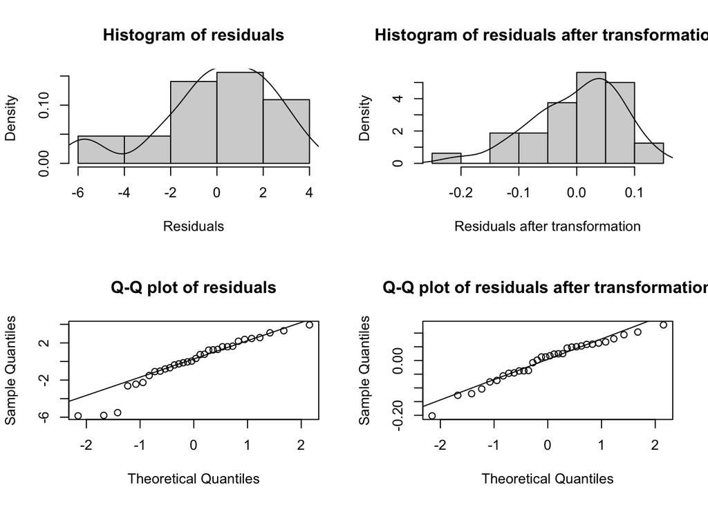

```
##
##   Box-Cox power transformation
## --------------------------------------------------------------
##
##   lambda.hat : -0.12
##
##
##   Shapiro-Wilk normality test (alpha = 0.05)
## --------------------------------------------------------------
##
##   statistic  : 0.9626522
##   p.value    : 0.3240839
##
##   Result     : Residuals are normal after transformation.
## --------------------------------------------------------------
```

**Komentarz do wykresów:**

- Histogramy reszt przed transformacją i po - Pierwszy wykres w lewym górnym rogu to histogram reszt przed transformacją. Pokazuje on rozkład różnic między wartościami obserwowanymi a wartościami przewidzianymi przez model. Histogram wykazuje pewne skupienie danych wokół zera, ale z lekkim skrzywieniem w lewo, co wskazuje na asymetrię (negatywną skośność) rozkładu. Na drugim rysunku rozkład reszt wydaje się być bardziej skoncentrowany wokół zera, co sugeruje, że transformacja przyczyniła się do poprawy normalności rozkładu.
- Wykresy kwantyl-kwantyl (Q-Q) reszt - Trzeci wykres znajdujący się w lewym dolnym rogu to wykres kwantyl-kwantyl (Q-Q) reszt przed transformacją. Jest to wizualne narzędzie do oceny, czy dane pochodzą z rozkładu normalnego. Teoretyczne kwantyle rozkładu normalnego są wykreślone na osi x, a empiryczne kwantyle próbki na osi y. Jeżeli punkty układają się wzdłuż prostej, sugeruje to, że rozkład jest normalny. Na tym wykresie punkty generalnie układają się wzdłuż linii, ale widać pewne odstępstwa, szczególnie na krańcach, co może wskazywać na obecność ciężkich ogonów rozkładów reszt. Transformacja poprawia ‘normalność’ reszt, co widać na czwartym rysunku.

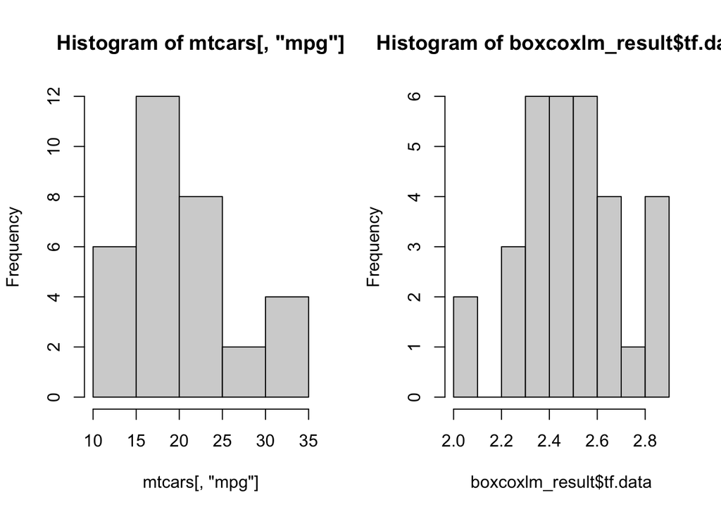

```r
par(mfrow=c(1,2))
hist(mtcars[, "mpg"]) #histogram oryginalnych danych
hist(boxcoxlm_result$tf.data) #histogram transformowanych danych
```

```r
boxcoxlm_result$method
```

```
## [1] "Estimating Box-Cox transformation parameter via least square estimation"
```

**Komentarz:**

Komenda `$method` w łatwy sposób pozwala sprawdzić metodę, jaką został estymowany parametr lambda transformacji Boxa-Coxa.

## boxcoxmeta - *Zespołowa Transformacja Boxa-Coxa Poprzez Metaanalizę dla Normalności Zmiennej*

**Opis**  
Funkcja `boxcoxmeta` wykonuje zespołową transformację Boxa-Coxa poprzez metaanalizę dla normalności zmiennej i dostarcza analizę graficzną.

**Użycie**

```
boxcoxmeta(data, lambda = seq(-3, 3, 0.01), nboot = 100, lambda2 = NULL,
          plot = TRUE, alpha = 0.05, verbose = TRUE)
```

**Argumenty**

- `data`: numeryczny wektor wartości danych.
- `lambda`: wektor zawierający sekwencję kandydatów na wartość lambda. Domyślnie ustawiony na zakres (-3, 3) z krokiem 0.01.
- `nboot`: liczba próbek Bootstrapowych używanych do oszacowania błędów standardowych oszacowań lambda.
- `lambda2`: numeryczna wartość dodatkowego parametru przesunięcia. Domyślnie ustawiona na `0`.
- `plot`: wartość logiczna określająca, czy generować histogram z linią gęstości oraz QQ-plot dla surowych i przekształconych danych. Domyślnie ustawiona na `TRUE`.
- `alpha`: poziom istotności do oceny normalności po transformacji. Domyślnie ustawiony na `0.05`.
- `verbose`: wartość logiczna określająca, czy wyświetlać wyniki w konsoli R. Domyślnie ustawiona na `TRUE`.

**Szczegóły**

Oznaczając $y$ jako zmienną w oryginalnej skali i $y'$ jako zmienną przekształconą, transformacja potęgowa Boxa-Coxa jest zdefiniowana przez:
$$y' =
\begin{cases}
\frac{y^\lambda - 1}{\lambda} & \text{jeśli } \lambda \neq 0 \\
\log(y) & \text{jeśli } \lambda = 0
\end{cases}$$

Jeśli dane zawierają jakiekolwiek obserwacje niedodatnie, można uwzględnić parametr przesunięcia $\lambda_2$ w transformacji, która jest zdefiniowana przez:

$$y' =
\begin{cases}
\frac{(y + \lambda_2)^\lambda - 1}{\lambda} & \text{jeśli }
\lambda \neq 0 \\
\log(y + \lambda_2) & \text{jeśli } \lambda = 0
\end{cases}$$

**Wartości zwracane**

Lista o klasie `"boxcoxmeta"` zawierająca następujące elementy:

- `method`: Preferowana metoda do oszacowania parametru transformacji Boxa-Coxa.
- `lambda.hat`: Oszacowanie parametru transformacji Boxa-Coxa zgodnie z odpowiednią metodą.
- `lambda2`: Dodatkowy parametr przesunięcia.
- `result`: Ramka danych zawierająca wynik.
- `alpha`: Poziom istotności do oceny normalności przekształconych reszt.
- `tf.data`: Przekształcony zbiór danych.
- `var.name`: Nazwa zmiennej.

**Przykład użycia**

```r
data(textile)
out <- boxcoxmeta(textile[,1])
```

```
##
##   Box-Cox power transformation via meta analysis
## -------------------------------------------------------
##
##   lambda.hat : -0.06550035
##
##
##   Normality tests for transformed data (alpha = 0.05)
## -------------------------------------------------------
##               Test Statistic   P.Value  Normality
## 1     Shapiro-Wilk 0.9877550 0.9820799 Not reject
## 2 Anderson Darling 0.1232611 0.9849573 Not reject
## 3      Jarque-Bera 0.3817128 0.8262512 Not reject
## -------------------------------------------------------
```

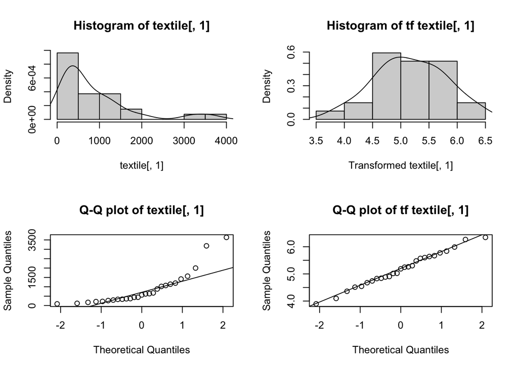

**Komentarz do wyników:**

Wyniki dla każdego z testów wskazują na to, że przetransformowane dane są bliskie rozkładowi normalnemu.

**Komentarz do wykresów:**

- Histogramy reszt przed transformacją i po - Pierwszy wykres w lewym górnym rogu przedstawia histogram zmiennej przed transformacją. Rozkład jest silnie skośny w prawo; większość danych jest skoncentrowana w niższych wartościach, a długi ogon rozciąga się w kierunku wyższych wartości. Taki rozkład może sugerować, że mamy do czynienia z danymi o rozkładzie wykładniczym lub innym rozkładzie dalekim od normalnego. Drugi wykres w prawym górnym rogu pokazuje histogram tej samej zmiennej po transformacji. Rozkład po transformacji jest znacznie bardziej symetryczny i przypomina kształtem rozkład normalny, co sugeruje, że transformacja była skuteczna w stabilizacji wariancji i sprowadzeniu rozkładu danych bliżej do normalnego.
- Wykresy kwantyl-kwantyl (Q-Q) reszt - wykres w lewym dolnym rogu to wykres Q-Q dla zmiennej przed transformacją. Wyraźnie widać, że punkty znacząco odchylają się od linii referencyjnej, co jest kolejnym dowodem na to, że oryginalne dane nie pochodzą z rozkładu normalnego. Dla wykresu Q-Q transformacji zmiennej, punkty na tym wykresie układają się znacznie bliżej linii referencyjnej w porównaniu z wykresem Q-Q przed transformacją. Oznacza to, że transformacja doprowadziła do sytuacji, w której rozkład danych jest bliższy normalności.

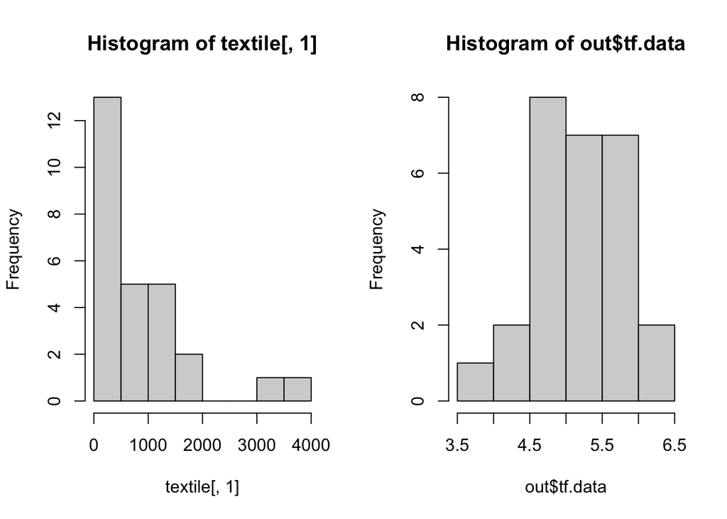

```r
par(mfrow=c(1,2))
hist(textile[,1]) #dane oryginalne
hist(out$tf.data) #dane przetransformowane
```

**Komentarz:**

Dane przed tranformacją nie przypominają rozkładu normalnego (bardziej wykładniczy), a po transformacji rozkład jest już zbliżony do rozkładu normalnego.

## boxcoxnc - *Transformacja Boxa-Coxa dla Normalności Zmiennej*

**Opis**  
Funkcja `boxcoxnc` wykonuje transformację Boxa-Coxa dla normalności zmiennej i dostarcza analizę graficzną.

**Użycie**

```
boxcoxnc(data, method = "sw", lambda = seq(-3, 3, 0.01), lambda2 = NULL,         plot = TRUE, alpha = 0.05, verbose = TRUE)
```

**Argumenty**

- `data`: numeryczny wektor wartości danych.
- `method`: ciąg znaków wybierający metodę estymacji parametru transformacji Boxa-Coxa. Domyślnie ustawiony na “sw” dla metody testu Shapiro-Wilka. Inne opcje to “ad” (test Andersona-Darlinga), “cvm” (test Cramera-von Misesa), “pt” (test Chi-kwadrat Pearsona), “sf” (test Shapiro-Francia), “lt” (test Lillieforsa), “jb” (test Jarque-Bera), “ac” (metoda sztucznej kowarianty), “mle” (estymacja metodą największej wiarygodności).
- `lambda`: wektor zawierający sekwencję kandydatów na wartość lambda. Domyślnie ustawiony na zakres (-3, 3) z krokiem 0.01.
- `lambda2`: wartość numeryczna dodatkowego parametru przesunięcia. Domyślnie ustawiona na `lambda2 = 0`.
- `plot`: wartość logiczna określająca, czy generować histogram z linią gęstości oraz QQ-plot dla surowych i przekształconych danych. Domyślnie ustawiona na `TRUE`.
- `alpha`: poziom istotności do oceny normalności po transformacji. Domyślnie ustawiony na `alpha = 0.05`.
- `verbose`: wartość logiczna określająca, czy wyświetlać wyniki w konsoli R.

**Szczegóły** Oznaczając $y$ jako zmienną w oryginalnej skali i $y'$ jako zmienną przekształconą, transformacja potęgowa Boxa-Coxa jest zdefiniowana przez:

$$y' = \left\{
\begin{array}{ll}
\frac{y^{\lambda}-1}{\lambda}, & \text{jeśli } \lambda \neq
0 \\
\log(y), & \text{jeśli } \lambda = 0
\end{array}
\right.$$

Jeśli dane zawierają jakiekolwiek obserwacje niedodatnie, można uwzględnić parametr przesunięcia $\lambda_2$ w transformacji, zdefiniowanej przez:

$$y' =\left\{
\begin{array}{ll}
\frac{(y + \lambda_2)^{\lambda}-1}{\lambda}, & \text{jeśli
} \lambda \neq 0 \\
\log(y + \lambda_2), & \text{jeśli } \lambda = 0
\end{array}
\right.$$

**Wartości zwracane**

Lista o klasie `"boxcoxnc"` zawierająca następujące elementy:

- `method`: Preferowana metoda do oszacowania parametru transformacji Boxa-Coxa.
- `lambda.hat`: Oszacowanie parametru transformacji Boxa-Coxa zgodnie z odpowiednią metodą.
- `lambda2`: Dodatkowy parametr przesunięcia.
- `statistic`: Statystyka testu normalności danych przekształconych na podstawie określonego testu normalności w metodzie. Dla metody sztucznej kowarianty, statystyka uzyskana jest przez test Shapiro-Wilka dla przekształconych danych.
- `p.value`: Wartość p testu normalności danych przekształconych na podstawie określonego testu normalności w metodzie.
- `alpha`: Poziom istotności do oceny normalności.
- `tf.data`: Przekształcony zbiór danych.
- `var.name`: Nazwa zmiennej.

**Przykład użycia**

```r
data(textile)
out <- boxcoxnc(textile[,1], method = "sw", plot = FALSE, verbose = FALSE)
print(out$lambda.hat) #Estymowany parametr transformacji Boxa-Coxa oparty na statystyce testowej Shapiro-Wilka:
```

```
## [1] -0.06
```

```r
print(out$p.value) #p-wartość testu Shapiro-WIlka dla transformowanych danych
```

```
## [1] 0.9821308
```

```r
print(out$tf.data) #Transformowane dane
```

```
##  [1] 5.391339 4.978224 4.811006 4.914613 4.744482 4.574181 4.419890 4.148641
##  [9] 3.943530 5.881626 5.773821 5.349873 5.669477 5.334701 5.095949 5.102258
## [17] 4.901977 4.607886 6.475795 6.394303 6.103675 5.948315 5.699720 5.272574
## [25] 5.741339 5.573345 4.958993
```

```r
out2 <- boxcoxnc(textile[,1], method = "sf", plot = FALSE, verbose = FALSE)
print(out2$lambda.hat) #Estymowany parametr transformacji Boxa-Coxa oparty na statystyce testowej Shapiro-Francia
```

```
## [1] -0.06
```

```r
print(out2$p.value) #p-wartość testu Shapiro-WIlka dla transformowanych danych
```

```
## [1] 0.9953051
```

```r
print(out2$tf.data) #Transformowane dane
```

```
##  [1] 5.391339 4.978224 4.811006 4.914613 4.744482 4.574181 4.419890 4.148641
##  [9] 3.943530 5.881626 5.773821 5.349873 5.669477 5.334701 5.095949 5.102258
## [17] 4.901977 4.607886 6.475795 6.394303 6.103675 5.948315 5.699720 5.272574
## [25] 5.741339 5.573345 4.958993
```

**Komentarz:**

Widać, że zarówno p-wartość, estymowana wartość lambda czy przetransformowane dane są bardzo podobne dla różnych metod estymacji parametru.

# Przedziały ufności

## confInt.boxcoxfr

**Opis** `confInt.boxcoxfr` oblicza średnią i asymetryczny przedział ufności dla danych przekształconych z powrotem w każdej grupie i rysuje ich słupki błędów z przedziałami ufności.

**Użycie**

```
## Metoda S3 dla klasy 'boxcoxfr'
confInt(x, level = 0.95, plot = TRUE, xlab = NULL, ylab = NULL, title = NULL,
        width = NULL, verbose = TRUE, ...)
```

**Argumenty**

- `x`: obiekt klasy `boxcoxfr`.
- `level`: poziom ufności.
- `plot`: wartość logiczna określająca, czy rysować słupki błędów z przedziałami ufności.
- `xlab`: etykieta osi X, domyślnie opis zmiennej `x`.
- `ylab`: etykieta osi Y, domyślnie opis zmiennej `y`.
- `title`: główny tytuł wykresu.
- `width`: numeryczna wartość określająca szerokość małych linii na górze i na dole słupków błędów (domyślnie ustawiona na 0.15).
- `verbose`: wartość logiczna określająca, czy wyświetlać wyniki w konsoli R.
- `...`: dodatkowe argument(y) dla metod.

**Szczegóły**

Przedział ufności w każdej grupie jest konstruowany osobno.

**Wartości zwracane**

Macierz z kolumnami przedstawiającymi średnią, dolne i górne granice przedziału ufności dla danych przekształconych z powrotem. Będą one oznaczone jako (1 - poziom)/2 i 1 - (1 - poziom)/2 w procentach (domyślnie 2,5% i 97,5%).

**Przykład użycia**

```r
data(AADT)
attach(AADT)
out <- boxcoxfr(aadt, class, verbose = FALSE)
confInt(out, level = 0.95)
```

```
##
##   Back transformed data
## -----------------------------------------
##                          Mean      2.5%     97.5%
## rural interstate    16414.561 10136.199 26166.703
## rural noninterstate  2004.065  1484.761  2688.367
## urban interstate    62916.623 45619.722 86159.962
## urban noninterstate 12551.073  9381.990 16693.347
## -----------------------------------------
```

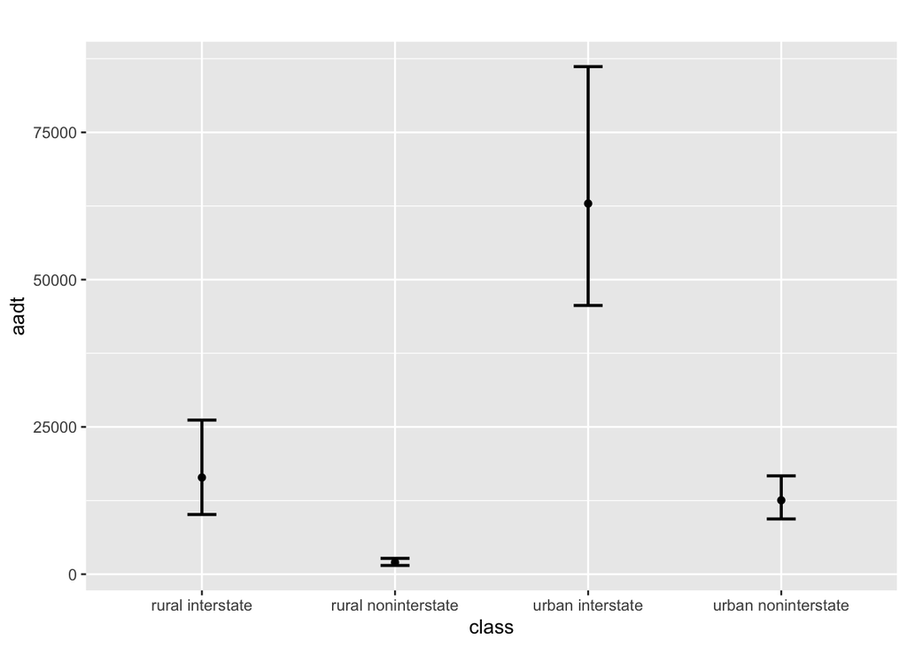

**Komentarz:**

`confInt` oblicza przedziały ufności dla przekształconych danych. Poziom ufności wynosi tutaj 95%, co jest standardową praktyką w analizie statystycznej.

Wyniki, które są już “odwrócone” po transformacji Boxa-Coxa, pokazują średnie wartości AADT (średni dobowy ruch roczny) dla czterech różnych typów dróg (rural interstate, rural noninterstate, urban interstate, urban noninterstate), razem z dolnymi i górnymi granicami przedziału ufności dla każdej kategorii.

Poniżej mamy też graficznie przedstawione przedziały wartości dla każdej z grup wraz z średnimi wyliczonymi dla nich.

## confInt.boxcoxmeta

**Opis**  
`confInt.boxcoxmeta` oblicza średnią i asymetryczny przedział ufności dla danych przekształconych z powrotem.

**Użycie**

```
## Metoda S3 dla klasy 'boxcoxmeta'
confInt(x, level = 0.95, verbose = TRUE, ...)
```

**Argumenty**

- `x`: obiekt klasy `boxcoxmeta`.
- `level`: poziom ufności.
- `verbose`: wartość logiczna określająca, czy wyświetlać wyniki w konsoli R.
- `...`: dodatkowe argument(y) dla metod.

**Szczegóły**

Konstruowany jest przedział ufności dla wybranej zmiennej.

**Wartości zwracane**

Macierz z kolumnami przedstawiającymi średnią, dolne i górne granice przedziału ufności dla danych przekształconych z powrotem. Będą one oznaczone jako (1 - poziom)/2 i 1 - (1 - poziom)/2 w procentach (domyślnie 2,5% i 97,5%).

**Przykład użycia**

```r
data(textile)
out <- boxcoxmeta(textile[,1], verbose = FALSE, plot = FALSE)
confInt(out, level = 0.95)
```

```
##
##   Back transformed data
## ---------------------------------------------
##                  Mean     2.5%    97.5%
## textile[, 1] 547.7037 379.0635 798.8224
## ---------------------------------------------
```

**Komentarz:** Przedstawiony jest 95% przedziały ufności “odwróconych” wyników po transformacji Boxa-Coxa, co oznacza, że reprezentowanych w oryginalnej skali danych.

```r
confInt(out, level = 0.9)
```

```
##
##   Back transformed data
## ---------------------------------------------
##                  Mean       5%      95%
## textile[, 1] 547.7037 403.3124 748.6044
## ---------------------------------------------
```

**Komentarz:** Możemy łatwo zmieniać poziom ufności za pomocą argumentu `level` dla funkcji `confInt()`.

## confInt.boxcoxnc

**Opis**  
`confInt.boxcoxnc` to ogólna funkcja służąca do obliczania średniej i asymetrycznego przedziału ufności dla danych przekształconych z powrotem.

**Użycie**

```
## Metoda S3 dla klasy 'boxcoxnc'
confInt(x, level = 0.95, verbose = TRUE, ...)
```

**Argumenty**

- `x`: obiekt klasy `boxcoxnc`.
- `level`: poziom ufności.
- `verbose`: wartość logiczna określająca, czy wyświetlać wyniki w konsoli R.
- `...`: dodatkowe argument(y) dla metod.

**Szczegóły**

Konstruowany jest przedział ufności dla wybranej zmiennej.

**Wartości zwracane**

Macierz z kolumnami przedstawiającymi średnią, dolne i górne granice przedziału ufności dla danych przekształconych z powrotem. Będą one oznaczone jako (1 - poziom)/2 i 1 - (1 - poziom)/2 w procentach (domyślnie 2,5% i 97,5%).

**Przykład użycia**

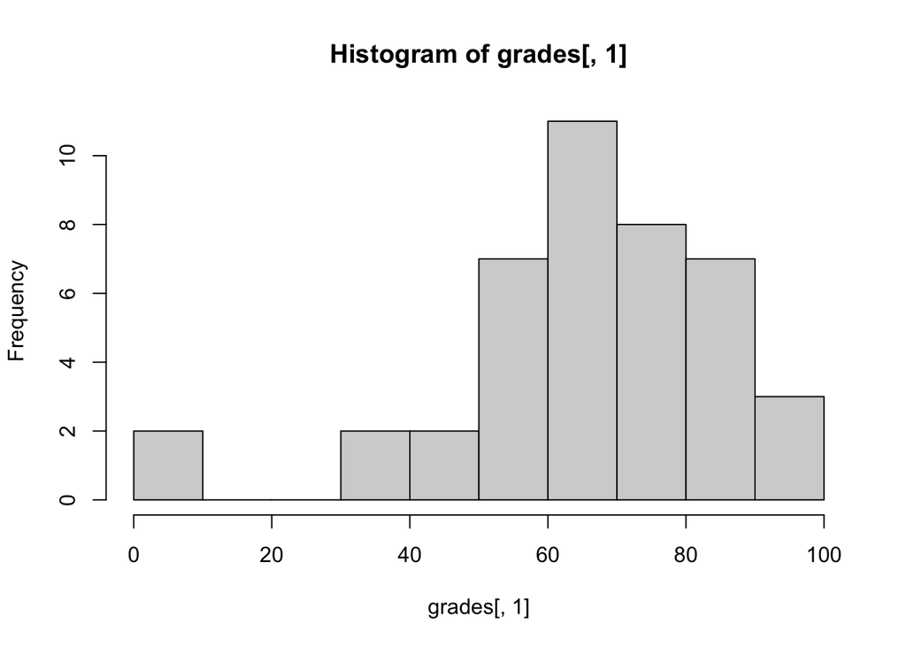

```r
data(grades)
hist(grades[,1])
```

**Komentarz:**

Histogram ocen uczniów, wygląda na rozkład lewoskośny.

```r
out <- boxcoxnc(grades[,1], verbose = FALSE, plot = FALSE)
confInt(out)
```

```
##
##   Back transformed data
## ---------------------------------------------
##                Mean     2.5%    97.5%
## grades[, 1] 68.1909 62.70209 73.30412
## ---------------------------------------------
```

**Komentarz:**

Przedstawiony jest 95% przedziały ufności “odwróconych” wyników po transformacji Boxa-Coxa, co oznacza, że reprezentowanych w oryginalnej skali danych.